# ML Final Project

Amanda, Tony, Harry, Geena

# Introduction

Data Cleaning Process to create shelter_clean.csv:

```r
#Load in datasets and initial cleaning
outcomes <- read_csv("Austin_Animal_Center_Outcomes_20250203.csv")
intakes <- read_csv("Austin_Animal_Center_Intakes_20250203.csv")

#
outcomes_clean <- outcomes |> mutate(OutcomeDate = as.Date(DateTime, '%m/%d/%Y %H:%M:%S')) |>
  select(-c(DateTime, MonthYear, `Outcome Subtype`, Name, `Animal Type`, Breed, Color))
intakes_clean <- intakes |>  mutate(IntakeDate = as.Date(DateTime, '%m/%d/%Y %H:%M:%S')) |> select(-c(DateTime, MonthYear))


#inner join the datasets
data <- merge(intakes_clean, outcomes_clean, by="Animal ID")

#Clean up merged dataset, and remove the duplicate rows from the multiple stays
clean <- data |>
  group_by(`Animal ID`) |>
  mutate(LengthofStay = OutcomeDate - IntakeDate) |>
  group_by(`Animal ID`) |>
  mutate(drop = LengthofStay < 0 |(LengthofStay >= max(LengthofStay) & n() > 1)) |>
  ungroup() |>
  filter(drop == F) |>
  select(-c("drop"))

#Create Date of Birth and then cast Age as a numeric variable
shelter_clean <- clean |>
  mutate(DOB = as.Date(`Date of Birth`, '%m/%d/%Y'),
         LengthofStay = as.numeric(LengthofStay),
         Age = case_when(
           str_detect(`Age upon Outcome`, "years") ~ as.numeric(gsub(" years", "", `Age upon Outcome`)),
           str_detect(`Age upon Outcome`, "months") ~ as.numeric(gsub(" months", "", `Age upon Outcome`))/12,
           str_detect(`Age upon Outcome`, "year") ~ as.numeric(1),
           str_detect(`Age upon Outcome`, "month") ~ as.numeric(1/12),
           str_detect(`Age upon Outcome`, "weeks") ~ as.numeric(gsub(" weeks", "", `Age upon Outcome`))/52,
           str_detect(`Age upon Outcome`, "week") ~ 1/52,
           str_detect(`Age upon Outcome`, "days") ~ as.numeric(gsub(" days", "", `Age upon Outcome`))/365,
           str_detect(`Age upon Outcome`, "day") ~ 1/365,
         )) |>
  select(`Animal ID`, Name, IntakeType = `Intake Type`, IntakeCondition = `Intake Condition`, AnimalType=`Animal Type`, Sex = `Sex upon Intake`, Age, OutcomeType=`Outcome Type`, OutcomeDate, LengthofStay, DOB)

#Make all of the categorical variables as factors
shelter_clean$AnimalType <- as.factor(shelter_clean$AnimalType)
shelter_clean$Sex <- as.factor(shelter_clean$Sex)
shelter_clean$IntakeCondition <- as.factor(case_when(
  shelter_clean$IntakeCondition %in% c("Sick", "Agonal", "Injured", "Med Attn", "Med Urgent", "Medical", "Neurologic", "Parvo") ~ "Medical",
  shelter_clean$IntakeCondition %in% c("Other", "Unknown") ~ "Other",
  TRUE ~ as.character(shelter_clean$IntakeCondition)
))

#Create transformed numeric variables
shelter_clean <- shelter_clean |> mutate(log_LOS = log(1+LengthofStay), log_Age = log(1+Age, 10))

#Create the logistic regression adoption variable for outcome type
shelter_clean <- shelter_clean |>
  mutate(Adoption = ifelse(OutcomeType == "Adoption", 1, 0), age2 = sqrt(Age)) |>
  filter(!is.na(Adoption))
```

# Methods

## Q1: Using the available predictors, is it possible to predict the length of stay of an animal that comes into the Austin animal shelter?

Initially, we tried to fit a multiple linear regression to predict the length of stay of an animal, which gave us the following results:

```r
lin_model <- lm(as.numeric(log_LOS) ~ log_Age + AnimalType + IntakeCondition + Sex + OutcomeType,data=shelter_clean)
summary(lin_model)
```

```
##
## Call:
## lm(formula = as.numeric(log_LOS) ~ log_Age + AnimalType + IntakeCondition +
##     Sex + OutcomeType, data = shelter_clean)
##
## Residuals:
##     Min      1Q  Median      3Q     Max
## -3.1971 -0.9027 -0.0616  0.7646  4.2664
##
## Coefficients:
##                            Estimate Std. Error t value Pr(>|t|)
## (Intercept)                 1.86359    0.27670   6.735 1.72e-11 ***
## log_Age                     0.82314    0.04499  18.297  < 2e-16 ***
## AnimalTypeCat               0.35355    0.12344   2.864  0.00419 **
## AnimalTypeDog               0.33357    0.12422   2.685  0.00726 **
## AnimalTypeLivestock         1.06387    0.41911   2.538  0.01115 *
## AnimalTypeOther            -0.10844    0.13171  -0.823  0.41035
## IntakeConditionBehavior     1.47172    0.36846   3.994 6.53e-05 ***
## IntakeConditionFeral        0.83719    0.44924   1.864  0.06241 .
## IntakeConditionMedical      0.68562    0.24701   2.776  0.00552 **
## IntakeConditionNeonatal     0.31897    0.25141   1.269  0.20458
## IntakeConditionNormal       0.64152    0.24648   2.603  0.00926 **
## IntakeConditionOther        0.93876    0.32482   2.890  0.00386 **
## IntakeConditionPregnant    -0.10362    0.32841  -0.316  0.75237
## SexIntact Male             -0.01089    0.02331  -0.467  0.64042
## SexNeutered Male           -0.42705    0.03970 -10.756  < 2e-16 ***
## SexSpayed Female           -0.58113    0.04487 -12.953  < 2e-16 ***
## SexUnknown                 -0.29665    0.05150  -5.761 8.60e-09 ***
## OutcomeTypeDied            -0.96410    0.09010 -10.701  < 2e-16 ***
## OutcomeTypeDisposal        -1.16342    0.12535  -9.281  < 2e-16 ***
## OutcomeTypeEuthanasia      -1.36624    0.06014 -22.718  < 2e-16 ***
## OutcomeTypeLost            -0.12045    0.75418  -0.160  0.87311
## OutcomeTypeMissing          0.59944    0.43434   1.380  0.16758
## OutcomeTypeReturn to Owner -1.85040    0.04128 -44.828  < 2e-16 ***
## OutcomeTypeRto-Adopt       -0.83339    0.09920  -8.401  < 2e-16 ***
## OutcomeTypeTransfer        -1.62134    0.02742 -59.140  < 2e-16 ***
## ---
## Signif. codes:  0 '***' 0.001 '**' 0.01 '*' 0.05 '.' 0.1 ' ' 1
##
## Residual standard error: 1.063 on 11018 degrees of freedom
## Multiple R-squared:  0.3873, Adjusted R-squared:  0.386
## F-statistic: 290.2 on 24 and 11018 DF,  p-value: < 2.2e-16
```

This model was not the best at predicting the length of stay of animals. The adjusted R-squared value was only about .386. If we look at the residual standard error though, we can see that our average error is only about 1 day, which is pretty good in context. However, we should also consider how many of the data points were from short term stays rather than longer term stereotypical adoption cases when interpreting the error of 1 day.

From the output, we can see that there isn’t a very strong linear relationship between the predictors and the response variable. However, before we move on to another model to predict the length of stay, we can try to regularize the model using lasso regression to see if we can suppress some of the less important predictors - which will be helpful especially as almost all of the predictors are indicator variables which are hard to control in regular linear regression.

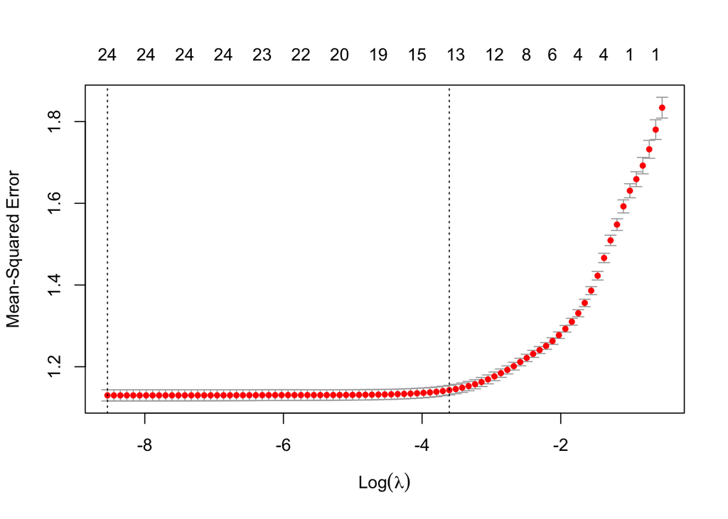

```r
#Lasso Regularization
set.seed(123)
response <- train$log_LOS
predictors <- model.matrix(log_LOS~log_Age + AnimalType + IntakeCondition + Sex + OutcomeType, shelter_clean)

ridge_model <- cv.glmnet(predictors[train_index, ], response, alpha = 1)
plot(ridge_model)
```

```r
ridge_model$lambda.min
```

```
## [1] 0.0001957493
```

```r
predict(glmnet(predictors[train_index, ], response, alpha = 1), type = "coefficients", s = ridge_model$lambda.min)[1:26,]
```

```
##                (Intercept)                (Intercept)
##                 2.23942312                 0.00000000
##                    log_Age              AnimalTypeCat
##                 0.77966731                 0.36263134
##              AnimalTypeDog        AnimalTypeLivestock
##                 0.33256952                 1.00684149
##            AnimalTypeOther    IntakeConditionBehavior
##                -0.08497721                 0.81137727
##       IntakeConditionFeral     IntakeConditionMedical
##                 0.42250905                 0.33493169
##    IntakeConditionNeonatal      IntakeConditionNormal
##                -0.05037263                 0.27513979
##       IntakeConditionOther    IntakeConditionPregnant
##                 0.55725545                -0.57126663
##             SexIntact Male           SexNeutered Male
##                -0.02879925                -0.41216049
##           SexSpayed Female                 SexUnknown
##                -0.58812078                -0.27574537
##            OutcomeTypeDied        OutcomeTypeDisposal
##                -0.98444129                -1.17275814
##      OutcomeTypeEuthanasia            OutcomeTypeLost
##                -1.39545065                -0.09495850
##         OutcomeTypeMissing OutcomeTypeReturn to Owner
##                 0.54234747                -1.83874598
##       OutcomeTypeRto-Adopt        OutcomeTypeTransfer
##                -0.79657906                -1.64028696
```

```r
pred <- predict(glmnet(predictors[train_index, ], response, alpha = 1), s = ridge_model$lambda.min, newx = predictors[-train_index, ])
sqrt(mean((pred - test$log_LOS)^2))
```

```
## [1] 1.071778
```

Finally, we can switch to a completely new method, and see if a regression tree can offer any additional information about which predictors are more important, and predict the length of stay accurately.

```r
#Try simple regression tree
tree <- tree(log_LOS~log_Age + AnimalType + IntakeCondition + Sex + OutcomeType, train)
summary(tree)
```

```
##
## Regression tree:
## tree(formula = log_LOS ~ log_Age + AnimalType + IntakeCondition +
##     Sex + OutcomeType, data = train)
## Variables actually used in tree construction:
## [1] "OutcomeType"     "log_Age"         "IntakeCondition" "Sex"
## Number of terminal nodes:  6
## Residual mean deviance:  1.045 = 9221 / 8828
## Distribution of residuals:
##     Min.  1st Qu.   Median     Mean  3rd Qu.     Max.
## -2.96500 -0.82610 -0.07474  0.00000  0.70840  4.10600
```

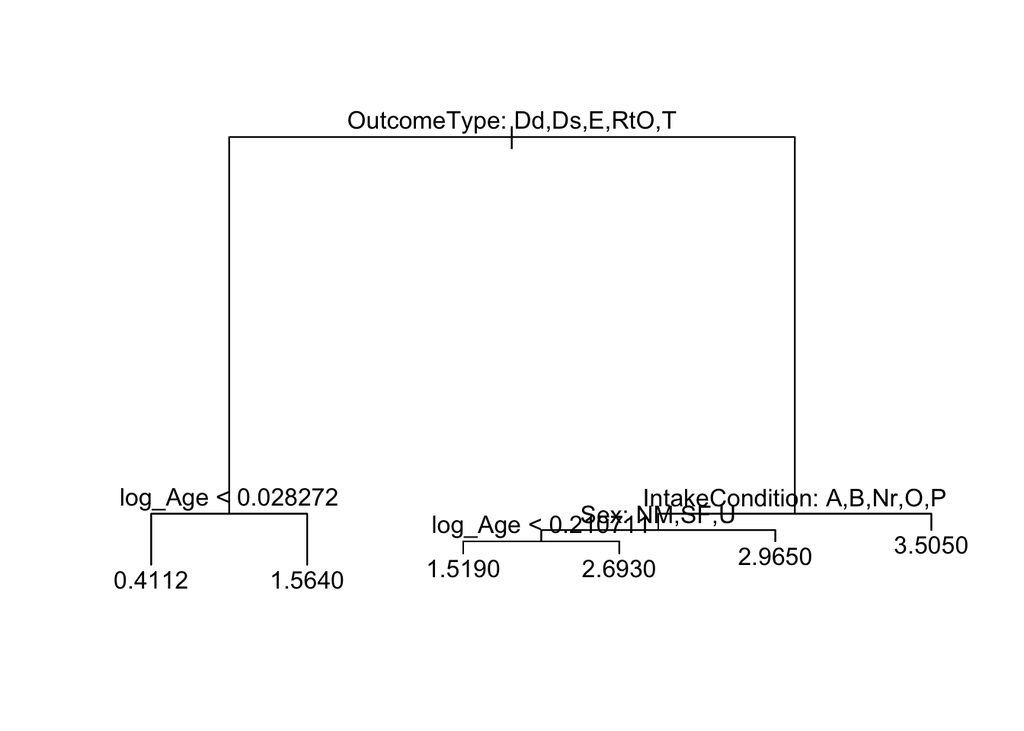

```r
plot(tree)
text(tree, pretty=1)
```

```r
yhat <- predict(tree, newdata = test)
RMSE(yhat, test$log_LOS)
```

```
## [1] 1.0444
```

From the output, we have a pretty clean, simple tree. Since there are only 6 terminal nodes, we probably don’t need to prune this tree, but we can check to be sure.

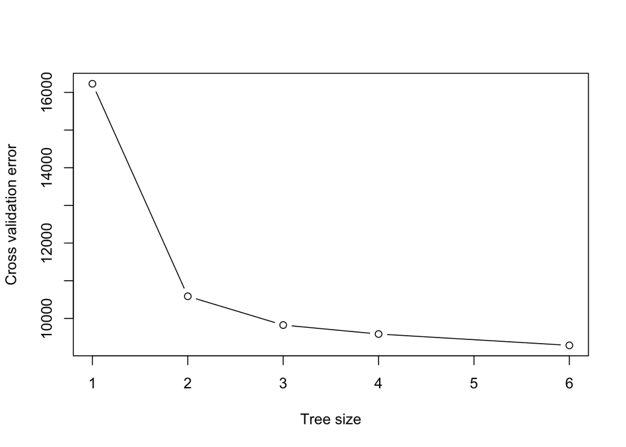

```r
#Prune?
set.seed(123)
cv_tree <- cv.tree(tree,  K = 10) #10-fold cross validation
plot(cv_tree$size, cv_tree$dev,  type = 'b', xlab = 'Tree size', ylab = 'Cross validation error')
```

```r
pred <- predict(tree, newdata = test)
RMSE(pred, test$log_LOS)^2
```

```
## [1] 1.090771
```

According to the graph, our original tree with 6 terminal nodes gives the best (lowest) error. Using this tree, we can see that our test error is 1.09, which is similar to our test errors from earlier methods. Maybe trying a random forest to help with potential variance in the model.

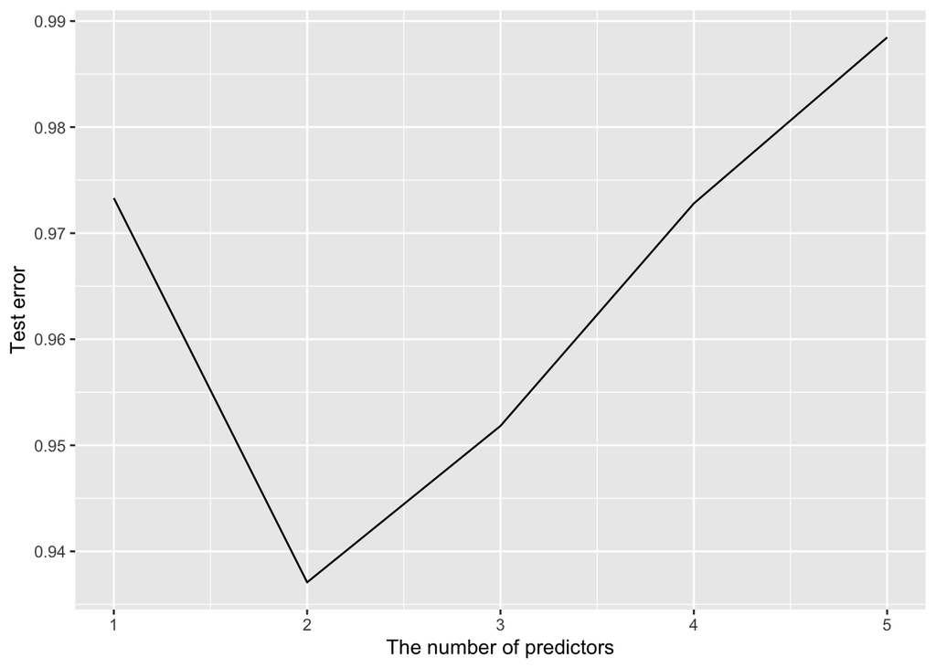

```r
#Random Forest
set.seed(123)
sequence_predictors <- seq(1, 5, by = 1)
# We create the number of predictors in {1, 2, ..., 5}
forest_test_error <- rep(0, length(sequence_predictors))
# We create a sequence of test errors with 0 values for each number of trees
for (i in 1:length(sequence_predictors))
{
  my_forest <- randomForest(log_LOS~log_Age + AnimalType + IntakeCondition + Sex + OutcomeType, data = train, mtry = sequence_predictors[i], ntree = 100, importance = TRUE)
  pred <- predict(my_forest, newdata = test)
  forest_test_error[i] <- RMSE(pred, test$log_LOS)^2
}

### Plot the test errors
forest_test_error_data_frame <- as.data.frame(forest_test_error)
ggplot(data = forest_test_error_data_frame, aes(x = seq(1,length(sequence_predictors), by = 1), y = forest_test_error)) + geom_line() + xlab("The number of predictors") + ylab("Test error")
```

```r
min <- which.min(forest_test_error)
min
```

```
## [1] 2
```

```r
my_forest <- randomForest(log_LOS~log_Age + AnimalType + IntakeCondition + Sex + OutcomeType, data=train, mtry = min, importance=TRUE)

pred <- predict(my_forest, newdata = test)
RMSE(pred, test$log_LOS)^2
```

```
## [1] 0.9351782
```

```r
importance(my_forest)
```

```
##                   %IncMSE IncNodePurity
## log_Age         100.77587     2577.7903
## AnimalType      109.40247      453.8519
## IntakeCondition 122.38927      638.5199
## Sex              88.79404      723.0069
## OutcomeType     136.58051     4736.6813
```

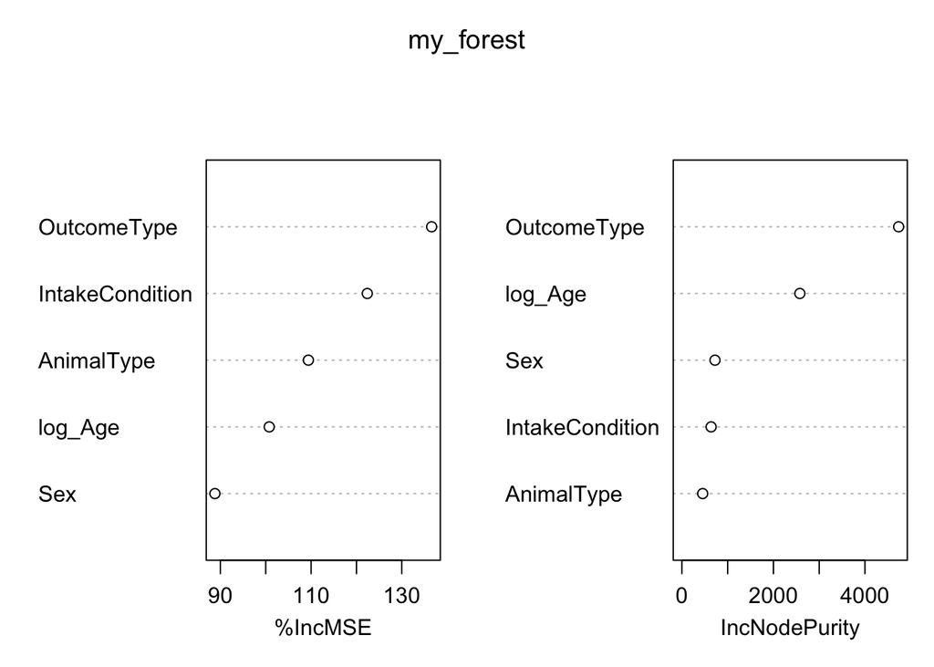

```r
varImpPlot(my_forest)
```

## Q2: Can we predict adoptability based on the age upon intake?

```r
library(plotROC)
library(ggplot2)
mean(shelter_clean$Adoption)
```

```
## [1] 0.6103414
```

About 61% animals were adopted in the dataset.

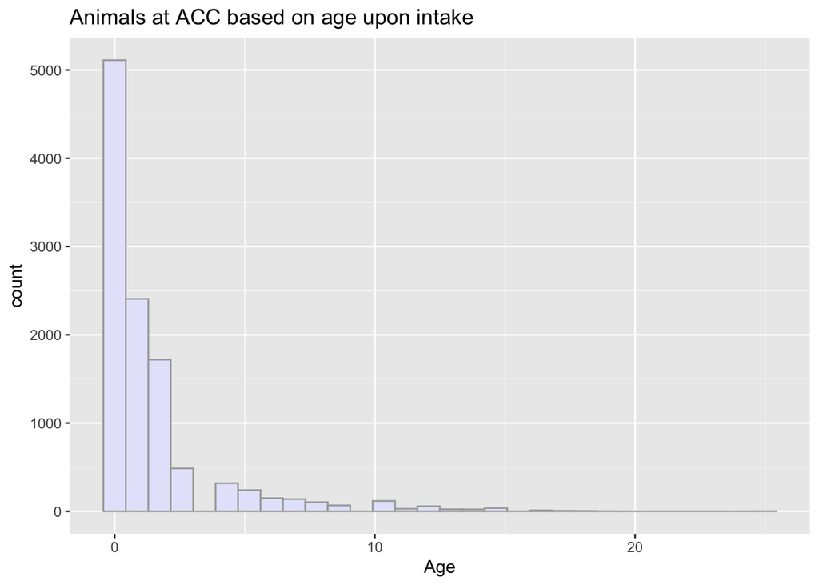

```r
ggplot(data = shelter_clean) + geom_histogram(aes(x = Age), fill="lavender",color="darkgray")+labs(title="Animals at ACC based on age upon intake")
```

The data is skewed heavily right; most of the animals are young.

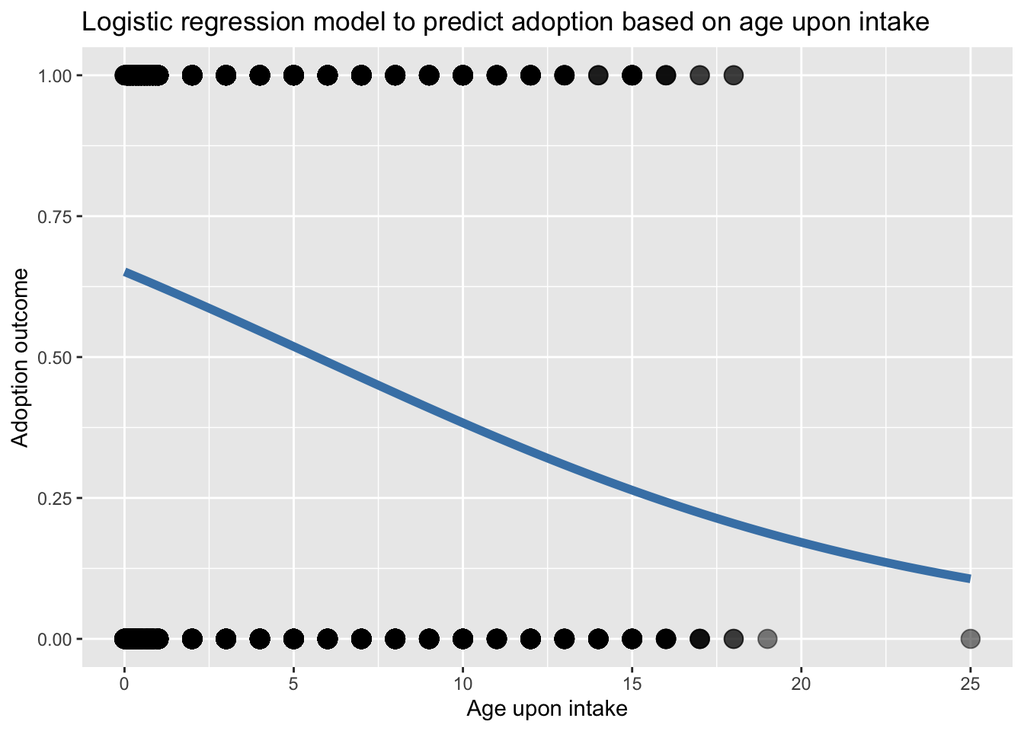

```r
# Represent the relationship with a model
shelter_clean |>
  ggplot(aes(x = Age, y = Adoption)) +
  # Consider a logistic regression model
  geom_smooth(method = "glm", se = FALSE,
              method.args = list(family = "binomial"),
              color = "steelblue", size = 2) +
  # Show original data
  geom_point(size = 4, alpha = 0.5) +
  labs(x = "Age upon intake",
       y = "Adoption outcome",
       title = "Logistic regression model to predict adoption based on age upon intake")
```

Logistic regression is compatible with our research question here because of the categorical nature of our question. When trying to predict whether or not an animal will or will not be adopted, logistic regression serves as a helpful model.

```r
# Fit the model
fit_log <- glm(Adoption ~ Age, data = shelter_clean, family = "binomial")

# Take a look at the model summary
summary(fit_log)
```

```
##
## Call:
## glm(formula = Adoption ~ Age, family = "binomial", data = shelter_clean)
##
## Coefficients:
##             Estimate Std. Error z value Pr(>|z|)
## (Intercept)  0.62524    0.02354   26.55   <2e-16 ***
## Age         -0.11009    0.00811  -13.57   <2e-16 ***
## ---
## Signif. codes:  0 '***' 0.001 '**' 0.01 '*' 0.05 '.' 0.1 ' ' 1
##
## (Dispersion parameter for binomial family taken to be 1)
##
##     Null deviance: 14767  on 11042  degrees of freedom
## Residual deviance: 14571  on 11041  degrees of freedom
## AIC: 14575
##
## Number of Fisher Scoring iterations: 4
```

The output gives the logit-form of the model which is: ln(p hat / 1-p hat) = 0.62524 - 0.11009 * Age, where p hat is the probability of the animal being adopted (1 = adopted, 0 = not adopted). This also shows that age is a significant predictor of adoption because of the significantly low Pr(>|z|) values.

```r
library(dplyr)
shelter_clean |>
  # Use the expression of the model
  mutate(probability = exp(0.62524 - 0.11009 * Age)/(1 + exp(0.62524 - 0.11009 * Age))) |>
  select(Age, Adoption, probability)
```

```
## # A tibble: 11,043 × 3
##      Age Adoption probability
##    <dbl>    <dbl>       <dbl>
##  1    16        0       0.243
##  2    16        0       0.243
##  3    16        1       0.243
##  4    16        1       0.243
##  5    16        0       0.243
##  6    15        0       0.264
##  7    17        1       0.223
##  8    15        1       0.264
##  9    15        0       0.264
## 10    14        0       0.286
## # ℹ 11,033 more rows
```

```r
shelter_predict <- shelter_clean |>
  # Create new variables for probability and predicted values
  mutate(probability = predict(fit_log, type = "response"),
         predicted = ifelse(probability > 0.3, 1, 0)) |>
  select(Age, Adoption, probability, predicted)

# Take a look
head(shelter_predict, 20)
```

```
## # A tibble: 20 × 4
##      Age Adoption probability predicted
##    <dbl>    <dbl>       <dbl>     <dbl>
##  1    16        0       0.243         0
##  2    16        0       0.243         0
##  3    16        1       0.243         0
##  4    16        1       0.243         0
##  5    16        0       0.243         0
##  6    15        0       0.264         0
##  7    17        1       0.223         0
##  8    15        1       0.264         0
##  9    15        0       0.264         0
## 10    14        0       0.286         0
## 11    15        0       0.264         0
## 12    16        0       0.243         0
## 13    15        0       0.264         0
## 14    14        0       0.286         0
## 15    13        0       0.309         1
## 16    12        0       0.333         1
## 17    14        0       0.286         0
## 18    18        1       0.205         0
## 19    15        1       0.264         0
## 20    15        0       0.264         0
```

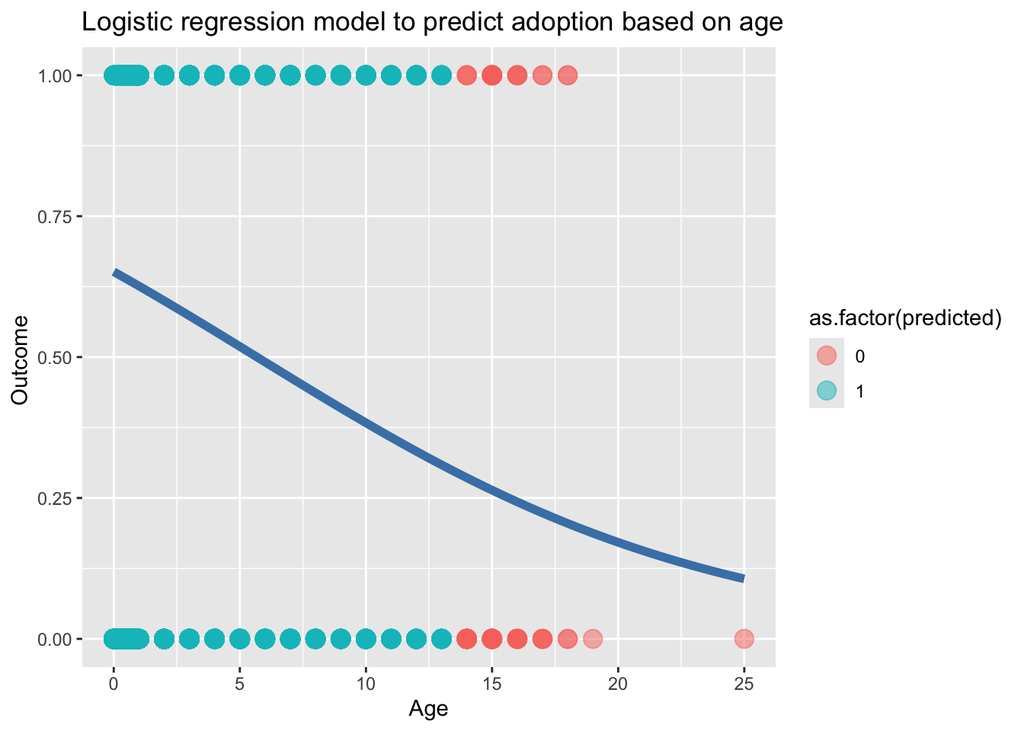

```r
# Represent the relationship with a model
shelter_predict |>
  ggplot(aes(x = Age, y = Adoption)) +
  # Consider a logistic regression model
  geom_smooth(method = "glm", se = FALSE,
              method.args = list(family = "binomial"),
              color = "steelblue", size = 2) +
  # Show original data, colored by predicted values
  geom_point(size = 4, alpha = 0.5,
             aes(color = as.factor(predicted))) + # add as.factor() to only see 2 categories
  labs(x = "Age",
       y = "Outcome ",
       title = "Logistic regression model to predict adoption based on age")
```

The blue points are predicted to have been adopted and the red ones are predicted to have been not adopted. Therefore, the top left corner of blue points shows the true positive points (predicted as adopted, actually adopted), while the bottom right red points show the true negative points (predicted as not adopted, actually not adopted).

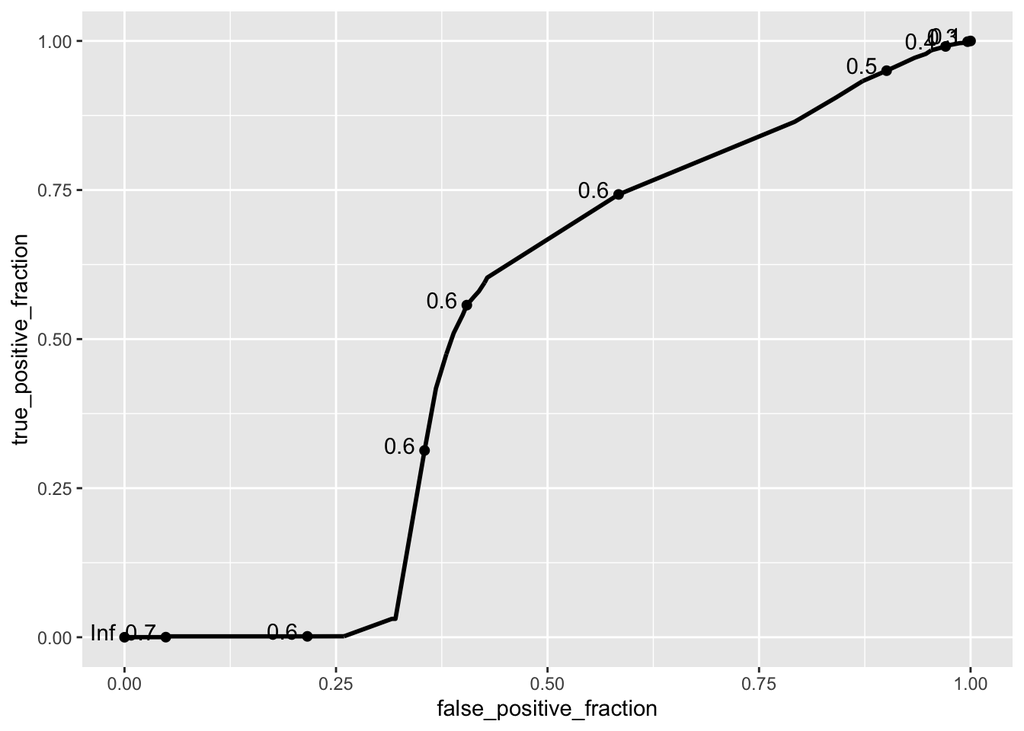

```r
ROC <- shelter_predict |>
  ggplot() +
  # the predictions are based on the probability values
  geom_roc(aes(d = Adoption, m = probability), n.cuts = 10)
ROC
```

```r
calc_auc(ROC)$AUC
```

```
## [1] 0.5118241
```

The area under curve (AUC) value of 0.512 demonstrates that the logistic regression model is not good at predicting. It is almost as good as random chance (which means it is bad at predicting).

## Q3: Can we predict adoption based on intake type?

```r
intakes <- read.csv("Austin_Animal_Center_Intakes_20250203.csv")
outcomes <- read.csv("Austin_Animal_Center_Outcomes_20250203.csv")

data <- merge(intakes, outcomes, by = "Animal.ID")

stray_abandoned <- data %>% filter(Intake.Type %in% c("Stray", "Abandoned"))
public_assist_owner_surrender <- data %>% filter(Intake.Type %in% c("Public Assist", "Owner Surrender"))


total_stray_abandoned <- nrow(stray_abandoned)
total_public_assist_owner_surrender <- nrow(public_assist_owner_surrender)


adopted_stray_abandoned <- sum(stray_abandoned$Outcome.Type == "Adoption")
adopted_public_assist_owner_surrender <- sum(public_assist_owner_surrender$Outcome.Type == "Adoption")


adopted_stray_abandoned_pct <- (adopted_stray_abandoned / total_stray_abandoned) * 100
adopted_public_assist_owner_surrender_pct <- (adopted_public_assist_owner_surrender / total_public_assist_owner_surrender) * 100


cat("Percentage of Stray or Abandoned intakes that were adopted:", adopted_stray_abandoned_pct, "%\n")
```

```
## Percentage of Stray or Abandoned intakes that were adopted: 62.44869 %
```

```r
cat("Percentage of Public Assist or Owner Surrender intakes that were adopted:", adopted_public_assist_owner_surrender_pct, "%\n")
```

```
## Percentage of Public Assist or Owner Surrender intakes that were adopted: 70.60415 %
```

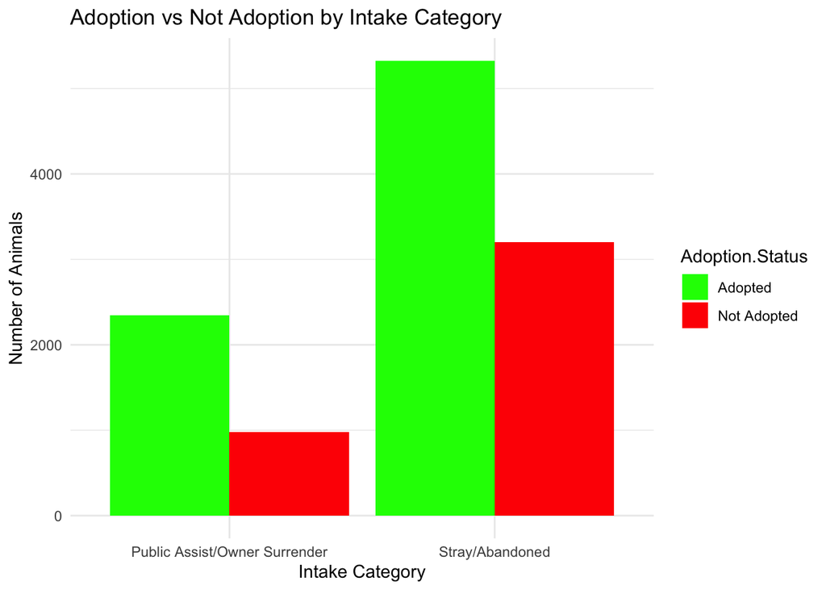

```r
data_merged <- merge(intakes, outcomes, by = "Animal.ID")

data_merged <- data_merged %>%
  mutate(Intake.Category = case_when(
    Intake.Type %in% c("Stray", "Abandoned") ~ "Stray/Abandoned",
    Intake.Type %in% c("Public Assist", "Owner Surrender") ~ "Public Assist/Owner Surrender",
    TRUE ~ "Other"
  ))

data_filtered <- data_merged %>%
  filter(Intake.Category != "Other")

#data
data_filtered <- data_filtered %>%
  mutate(Adoption.Status = ifelse(Outcome.Type == "Adoption", "Adopted", "Not Adopted"))
adoption_counts <- data_filtered %>%
  group_by(Intake.Category, Adoption.Status) %>%
  summarise(Count = n(), .groups = "drop")

#bar chart
ggplot(adoption_counts, aes(x = Intake.Category, y = Count, fill = Adoption.Status)) +
  geom_bar(stat = "identity", position = "dodge") +
  labs(title = "Adoption vs Not Adoption by Intake Category",
       x = "Intake Category",
       y = "Number of Animals") +
  theme_minimal() +
  scale_fill_manual(values = c("Adopted" = "green", "Not Adopted" = "red"))
```

Our initial hypothesis for this question was that because animals that are in a shelter because of public assist or owner surrender have more human experience, and thus are more likely to be adopted compared to strays. From initial analysis we see that there seem to be proportionally more animals adopted that are in the shelter because of public assistance or owner surrender that animals that are stray. This does not confirm our hypothesis, however. To further confirm this we calculate the adoption rates of public assist/owner surrender and stray/abandoned animals and found that public assist/owner surrendered animals had a 70.60% adoption rate as compared to the former which had a 62.45% adoption rate. While the adoption rate is greater for the animals with prior human interaction, is this difference significant?

```r
#SIGNIFICANCE USING PROPORTION TEST
stray_abandoned <- data_filtered %>% filter(Intake.Category == "Stray/Abandoned")
surrender <- data_filtered %>% filter(Intake.Category == "Public Assist/Owner Surrender")

#Adoption counts
adopted_stray <- sum(stray_abandoned$Adoption.Status == "Adopted")
not_adopted_stray <- sum(stray_abandoned$Adoption.Status != "Adopted")

adopted_surrender <- sum(surrender$Adoption.Status == "Adopted")
not_adopted_surrender <- sum(surrender$Adoption.Status != "Adopted")

#Proportion test
prop.test(
  x = c(adopted_stray, adopted_surrender),      # number of adoptions
  n = c(nrow(stray_abandoned), nrow(surrender)),# total in each group
  correct = FALSE                                # disables Yates' correction
)
```

```
##
##  2-sample test for equality of proportions without continuity correction
##
## data:  c(adopted_stray, adopted_surrender) out of c(nrow(stray_abandoned), nrow(surrender))
## X-squared = 69.729, df = 1, p-value < 2.2e-16
## alternative hypothesis: two.sided
## 95 percent confidence interval:
##  -0.10013640 -0.06297271
## sample estimates:
##    prop 1    prop 2
## 0.6244869 0.7060415
```

By using a proportion test we can test the significance of this difference. The resulting p-value < 2.2e-16 confirms that this difference in adoption rates is in fact significant at a 0.05 confidence interval. Now that we know that the intake type is a significant predictor for an animals adoption, we can begin fitting models with this predictor.

```r
#LOGISTIC REG MODEL
data_filtered$AdoptedBinary <- ifelse(data_filtered$Adoption.Status == "Adopted", 1, 0)

data_filtered$Intake.Category <- factor(data_filtered$Intake.Category)

model <- glm(AdoptedBinary ~ Intake.Category, data = data_filtered, family = "binomial")

summary(model)
```

```
##
## Call:
## glm(formula = AdoptedBinary ~ Intake.Category, family = "binomial",
##     data = data_filtered)
##
## Coefficients:
##                                Estimate Std. Error z value Pr(>|z|)
## (Intercept)                     0.87624    0.03806  23.025   <2e-16 ***
## Intake.CategoryStray/Abandoned -0.36760    0.04414  -8.328   <2e-16 ***
## ---
## Signif. codes:  0 '***' 0.001 '**' 0.01 '*' 0.05 '.' 0.1 ' ' 1
##
## (Dispersion parameter for binomial family taken to be 1)
##
##     Null deviance: 15388  on 11853  degrees of freedom
## Residual deviance: 15317  on 11852  degrees of freedom
## AIC: 15321
##
## Number of Fisher Scoring iterations: 4
```

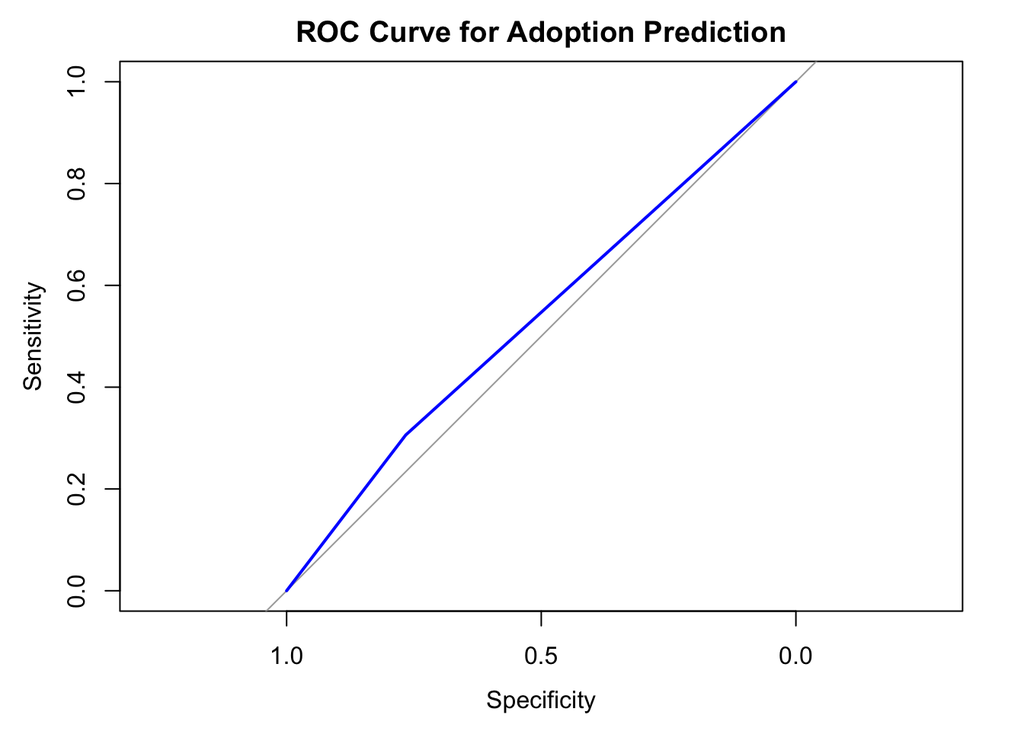

```r
library(pROC)
predicted_probs <- predict(model, type = "response")
true_labels <- data_filtered$AdoptedBinary
roc_obj <- roc(true_labels, predicted_probs)
plot(roc_obj, main = "ROC Curve for Adoption Prediction", col = "blue", lwd = 2)
```

```r
auc_value <- auc(roc_obj)
print(paste("AUC:", round(auc_value, 3)))
```

```
## [1] "AUC: 0.536"
```

We chose the logistic regression model because of its advantage of ease of implementation as well as it being well-suited for binary classification tasks. It turns out, however, that it was not very good at predicting adoption based on intake type. Just from the ROC curve alone we can see that the curve does not even come close to the top left corner of the graph. To further confirm this we find that the AUC=0.536, which signifies that the model is equivalent to random guessing.It became apparent that using just intake type as a predictor isn’t great for fitting models. Thus we added additional predictors to get a better model.

```r
library(dplyr)
library(pROC)

convert_age <- function(age_string) {
  age_string <- tolower(age_string)
  if (grepl("day", age_string)) {
    as.numeric(gsub("[^0-9]", "", age_string)) / 365
  } else if (grepl("week", age_string)) {
    as.numeric(gsub("[^0-9]", "", age_string)) / 52
  } else if (grepl("month", age_string)) {
    as.numeric(gsub("[^0-9]", "", age_string)) / 12
  } else if (grepl("year", age_string)) {
    as.numeric(gsub("[^0-9]", "", age_string))
  } else {
    NA
  }
}

data_model <- data_filtered %>%
  mutate(
    IntakeCategory = ifelse(Intake.Category == "Stray/Abandoned", "Stray", "Surrender"),
    IntakeCategory = as.factor(IntakeCategory),
    AgeYears = sapply(`Age.upon.Intake`, convert_age),
    IntakeCondition = as.factor(Intake.Condition),
    AnimalType = as.factor(Animal.Type.y),
    Sex = as.factor(Sex.upon.Intake),
    AdoptedBinary = as.factor(AdoptedBinary)
  ) %>%
  filter(!is.na(AgeYears) & !is.na(IntakeCondition) & !is.na(Sex))

set.seed(123)
n <- nrow(data_model)
train_idx <- sample(1:n, size = 0.8 * n)

train_data <- data_model[train_idx, ]
test_data <- data_model[-train_idx, ]

#logistic
model <- glm(AdoptedBinary ~ IntakeCategory + AgeYears + IntakeCondition + AnimalType + Sex,
             data = train_data, family = "binomial")

pred_probs <- predict(model, newdata = test_data, type = "response")
pred_labels <- ifelse(pred_probs > 0.5, "1", "0")
true_labels <- as.character(test_data$AdoptedBinary)

roc_obj <- roc(as.numeric(true_labels), pred_probs)
auc_val <- auc(roc_obj)

accuracy <- mean(pred_labels == true_labels)

summary(model)
```

```
##
## Call:
## glm(formula = AdoptedBinary ~ IntakeCategory + AgeYears + IntakeCondition +
##     AnimalType + Sex, family = "binomial", data = train_data)
##
## Coefficients:
##                            Estimate Std. Error z value Pr(>|z|)
## (Intercept)                 3.82106    0.78922   4.842 1.29e-06 ***
## IntakeCategorySurrender     0.06809    0.05948   1.145  0.25231
## AgeYears                   -0.16438    0.01087 -15.117  < 2e-16 ***
## IntakeConditionAgonal     -14.05803  535.41158  -0.026  0.97905
## IntakeConditionBehavior    -0.67278    0.78907  -0.853  0.39386
## IntakeConditionFeral       -0.57180    1.12087  -0.510  0.60996
## IntakeConditionInjured     -0.27109    0.65708  -0.413  0.67992
## IntakeConditionMed Attn    -0.59408    0.75304  -0.789  0.43017
## IntakeConditionMed Urgent -13.59925  218.58515  -0.062  0.95039
## IntakeConditionMedical     -0.32743    0.67224  -0.487  0.62620
## IntakeConditionNeonatal    -1.38732    0.66505  -2.086  0.03698 *
## IntakeConditionNeurologic -12.22953  535.41156  -0.023  0.98178
## IntakeConditionNormal       0.84828    0.65415   1.297  0.19472
## IntakeConditionOther       -0.33566    0.94054  -0.357  0.72119
## IntakeConditionParvo      -13.87100  378.32321  -0.037  0.97075
## IntakeConditionPregnant     0.42971    0.82608   0.520  0.60294
## IntakeConditionSick        -0.15135    0.66004  -0.229  0.81863
## IntakeConditionUnknown      0.94756    0.88423   1.072  0.28389
## AnimalTypeCat              -3.38453    0.43968  -7.698 1.39e-14 ***
## AnimalTypeDog              -3.42400    0.44101  -7.764 8.23e-15 ***
## AnimalTypeLivestock         1.33710    1.30429   1.025  0.30529
## AnimalTypeOther            -2.68242    0.49546  -5.414 6.16e-08 ***
## SexIntact Male             -0.08980    0.05415  -1.658  0.09727 .
## SexNeutered Male            0.23910    0.08580   2.787  0.00533 **
## SexSpayed Female            0.50675    0.09946   5.095 3.49e-07 ***
## SexUnknown                 -3.73727    0.23807 -15.698  < 2e-16 ***
## ---
## Signif. codes:  0 '***' 0.001 '**' 0.01 '*' 0.05 '.' 0.1 ' ' 1
##
## (Dispersion parameter for binomial family taken to be 1)
##
##     Null deviance: 12233  on 9482  degrees of freedom
## Residual deviance: 10556  on 9457  degrees of freedom
## AIC: 10608
##
## Number of Fisher Scoring iterations: 12
```

```r
cat("AUC:", round(auc_val, 3), "\n")
```

```
## AUC: 0.731
```

```r
cat("Accuracy:", round(accuracy, 3), "\n")
```

```
## Accuracy: 0.712
```

Now that we have more predictors, we used 80% of the data as training and 20% as testing to get a decent logistic regression model with an AUC of 0.731 and an accuracy of 0.712. It also seems that the most significant predictors are age and animal type. For the sake of finding a better model, we will try fitting a KNN classification with multiple predictors to see if it is better.

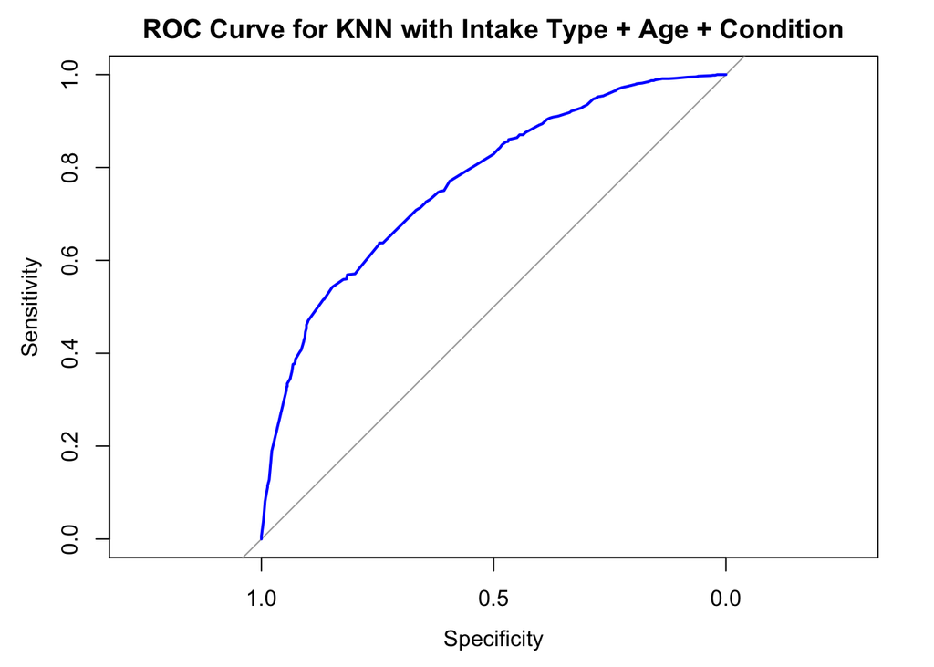

```r
library(class)
library(pROC)
library(dplyr)
convert_age <- function(age_string) {
  age_string <- tolower(age_string)
  if (grepl("day", age_string)) {
    as.numeric(gsub("[^0-9]", "", age_string)) / 365
  } else if (grepl("week", age_string)) {
    as.numeric(gsub("[^0-9]", "", age_string)) / 52
  } else if (grepl("month", age_string)) {
    as.numeric(gsub("[^0-9]", "", age_string)) / 12
  } else if (grepl("year", age_string)) {
    as.numeric(gsub("[^0-9]", "", age_string))
  } else {
    NA
  }
}

data_knn <- data_filtered %>%
  mutate(
    IntakeNum = ifelse(Intake.Category == "Stray/Abandoned", 1, 0),
    AgeNum = sapply(Age.upon.Intake, convert_age),
    IntakeConditionNum = as.numeric(factor(Intake.Condition)),
    AdoptedBinary = as.factor(AdoptedBinary)
  ) %>%
  filter(!is.na(AgeNum) & !is.na(Intake.Condition))  # Drop NAs

set.seed(123)
n <- nrow(data_knn)
train_idx <- sample(1:n, size = 0.8 * n)

train <- data_knn[train_idx, ]
test  <- data_knn[-train_idx, ]

# Features for KNN (scaled for fair distance calculation)
train_X <- scale(as.matrix(train[, c("IntakeNum", "AgeNum", "IntakeConditionNum")]))
test_X  <- scale(as.matrix(test[, c("IntakeNum", "AgeNum", "IntakeConditionNum")]),
                 center = attr(train_X, "scaled:center"),
                 scale = attr(train_X, "scaled:scale"))

train_y <- train$AdoptedBinary
test_y  <- test$AdoptedBinary
knn_pred <- knn(train = train_X, test = test_X, cl = train_y, k = 5, prob = TRUE)

knn_prob <- ifelse(knn_pred == "1", attr(knn_pred, "prob"), 1 - attr(knn_pred, "prob"))
test_y_num <- as.numeric(as.character(test_y))

#ROC and AUC
knn_roc <- roc(test_y_num, knn_prob)
plot(knn_roc, main = "ROC Curve for KNN with Intake Type + Age + Condition", col = "blue", lwd = 2)
```

```r
auc_val <- auc(knn_roc)
print(paste("AUC:", round(auc_val, 3)))
```

```
## [1] "AUC: 0.768"
```

Since we have classification variables we use KNN classification and attempted to predict adoption based on intake type, intake condition, and age. Already from the ROC curve we have a great model, since the curve is closer to the top left of the graph. This is confirmed with the AUC of 0.768, signifying a good model and marginally better than the logistic regression model previously fitted.

# Conclusion and Future Work

Q1: Predicting Length of Stay

Q2: Predicting adoption based on intake age

- Age is a significant predictor for this model, with an AUC of 0.511. The logistic regression performance was pretty poor, which may be due to longer stays. In the future, we could probably do additional classification models such as KNN, or adding additional predictors.

Q3: Predicting adoption based on intake type

- Intake type is a significant predictor, however the logistic regression was not good KNN classification approach was fairly decent (AUC = 0.768).

# Contributions

Contributions mirror our presentations.

**Amanda**: Data cleaning part of introduction, and the first half of Question 1

**Harry**: All of Question 3

**Tony**: Introduction and second half of Question 1.

**Geena**: All of Question 2 (initial observations, logistic regression, logistic regression visualization, ROC plot, AUC value)